# What Loan Characterics Affect BorrowerAPR

## by Lina AlKhodair

## Investigation Overview

> In this presentation, we will investigate different visualizations to find out which loan characteristics affect the borrower APR and study their relationships. The main characteristics explored are original loan amount, borrower's Prosper rating, and borrowerAPR.

## Dataset Overview

> The dataset contains 113,937 loans. Each row has information on borrowerAPR, Prosper rating, loan original amount, loan term etc. This study will be analyzing factors that could inflence borrow's APR.

## BorrowerAPR Distribution

> For the BorrowerAPR distribution there is a semi large peak centered around 0.2. Also a very exceptional high around 0.35 and small amount of loans have APR greater than 0.4.

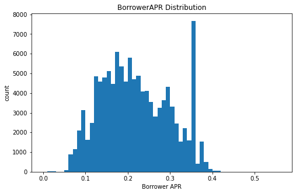

## BorrowerAPR vs. Loan Original Amount

> BorrowerAPR decreases with the increase of loan amount. So, it is a negative correlation between LoanOriginalAmount and BorrowerAPR.

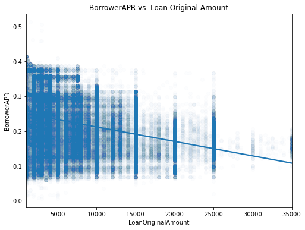

## BorrowerAPR vs. Prosper Rating

> From the relationship of BorrowerAPR vs. ProsperRating we can conclude that borrower APR decreases when increasing rating. Borrowers with the greater Prosper ratings have the lower APR. Thus, negative correlation.

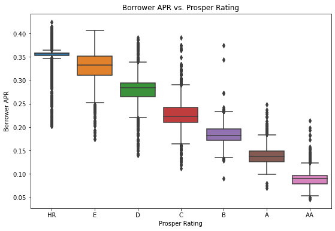

## BorrowerAPR vs Loan Original Amount on each ProsperRatings

> The relationship between LoanOriginalAmount and BorrowerAPR starts out with negative when ProsperRating is low from HR and then changes to positive when ProsperRating is increased to A or better. Also, when increasing the PropserRating LoanOriginalAmount increases too.

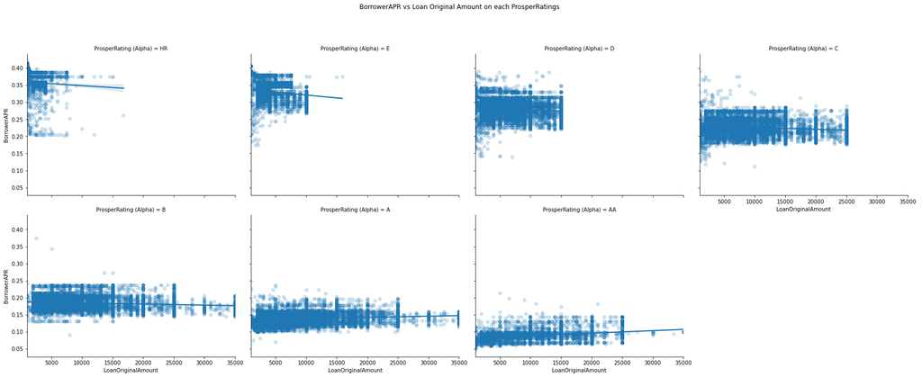